# ITCS 1880: Final Project

By Michael Beebe

Loading in dependencies

```r
library(tidyverse)
library(glue)
library(ggplot2)
library(hrbrthemes)
library(psych)
library(graphics)
```

Loading in dataset to be analyzed

```r
customer_data <- read.csv("Data/Mall_Customers.csv")
```

# Exploratory Data Analysis

The number of rows and the number of columns in the data set.

```r
nrow(customer_data)
```

```
## [1] 200
```

```r
ncol(customer_data)
```

```
## [1] 5
```

The names of the columns in the data set

```r
colnames(customer_data)
```

```
## [1] "CustomerID"             "Gender"                 "Age"
## [4] "Annual.Income..k.."     "Spending.Score..1.100."
```

The top 10 rows of the data set

```r
head(customer_data, 10)
```

```
##    CustomerID Gender Age Annual.Income..k.. Spending.Score..1.100.
## 1           1   Male  19                 15                     39
## 2           2   Male  21                 15                     81
## 3           3 Female  20                 16                      6
## 4           4 Female  23                 16                     77
## 5           5 Female  31                 17                     40
## 6           6 Female  22                 17                     76
## 7           7 Female  35                 18                      6
## 8           8 Female  23                 18                     94
## 9           9   Male  64                 19                      3
## 10         10 Female  30                 19                     72
```

The class of the dataset and each column

```r
class(customer_data)
```

```
## [1] "data.frame"
```

```r
lapply(customer_data, class)
```

```
## $CustomerID
## [1] "integer"
##
## $Gender
## [1] "character"
##
## $Age
## [1] "integer"
##
## $Annual.Income..k..
## [1] "integer"
##
## $Spending.Score..1.100.
## [1] "integer"
```

Summarize the data in the Mall Customers data set. Be sure to include: Min, Max, Mean, Median, Quartiles and Standard Deviation:

### Age

Min

```r
glue("Min Age: {min(customer_data$Age)}")
```

```
## Min Age: 18
```

Max

```r
glue("Max Age: {max(customer_data$Age)}")
```

```
## Max Age: 70
```

Mean

```r
glue("Mean Age: {mean(customer_data$Age)}")
```

```
## Mean Age: 38.85
```

Median

```r
glue("Median Age: {median(customer_data$Age)}")
```

```
## Median Age: 36
```

Quartiles

```r
quantile(customer_data$Age)
```

```
##    0%   25%   50%   75%  100%
## 18.00 28.75 36.00 49.00 70.00
```

Standard Deviation

```r
glue("Standard Deviation of Age: {sd(customer_data$Age)}")
```

```
## Standard Deviation of Age: 13.9690073315589
```

```r
describe(customer_data)
```

```
##                        vars   n   mean    sd median trimmed   mad min max range
## CustomerID                1 200 100.50 57.88  100.5  100.50 74.13   1 200   199
## Gender*                   2 200   1.44  0.50    1.0    1.43  0.00   1   2     1
## Age                       3 200  38.85 13.97   36.0   37.94 16.31  18  70    52
## Annual.Income..k..        4 200  60.56 26.26   61.5   59.64 24.46  15 137   122
## Spending.Score..1.100.    5 200  50.20 25.82   50.0   50.31 29.65   1  99    98
##                         skew kurtosis   se
## CustomerID              0.00    -1.22 4.09
## Gender*                 0.24    -1.95 0.04
## Age                     0.48    -0.71 0.99
## Annual.Income..k..      0.32    -0.15 1.86
## Spending.Score..1.100. -0.05    -0.86 1.83
```

```r
describe.by(customer_data, group = customer_data$Gender)
```

```
##
##  Descriptive statistics by group
## group: Female
##                        vars   n  mean    sd median trimmed   mad min max range
## CustomerID                1 112 97.56 58.28   94.5   96.98 73.39   3 197   194
## Gender*                   2 112  1.00  0.00    1.0    1.00  0.00   1   1     0
## Age                       3 112 38.10 12.64   35.0   37.28 14.83  18  68    50
## Annual.Income..k..        4 112 59.25 26.01   60.0   58.29 26.69  16 126   110
## Spending.Score..1.100.    5 112 51.53 24.11   50.0   51.61 27.43   5  99    94
##                        skew kurtosis   se
## CustomerID             0.09    -1.23 5.51
## Gender*                 NaN      NaN 0.00
## Age                    0.50    -0.58 1.19
## Annual.Income..k..     0.29    -0.48 2.46
## Spending.Score..1.100. 0.03    -0.81 2.28
## ------------------------------------------------------------
## group: Male
##                        vars  n   mean    sd median trimmed   mad min max range
## CustomerID                1 88 104.24 57.48  106.5  104.93 68.20   1 200   199
## Gender*                   2 88   1.00  0.00    1.0    1.00  0.00   1   1     0
## Age                       3 88  39.81 15.51   37.0   39.03 16.31  18  70    52
## Annual.Income..k..        4 88  62.23 26.64   62.5   61.39 23.72  15 137   122
## Spending.Score..1.100.    5 88  48.51 27.90   50.0   48.46 34.10   1  97    96
##                         skew kurtosis   se
## CustomerID             -0.11    -1.20 6.13
## Gender*                  NaN      NaN 0.00
## Age                     0.39    -1.00 1.65
## Annual.Income..k..      0.34     0.13 2.84
## Spending.Score..1.100. -0.06    -1.04 2.97
```

### Annual Income ($1,000’s)

Min

```r
glue("Min Annual Income in $1,000's: {min(customer_data$Annual.Income..k..)}")
```

```
## Min Annual Income in $1,000's: 15
```

Max

```r
glue("Max Annual Income in $1,000's: {max(customer_data$Annual.Income..k..)}")
```

```
## Max Annual Income in $1,000's: 137
```

Mean

```r
glue("Mean Annual Income in $1,000's: {mean(customer_data$Annual.Income..k..)}")
```

```
## Mean Annual Income in $1,000's: 60.56
```

Median

```r
glue("Median Annual Income in $1,000's: {median(customer_data$Annual.Income..k..)}")
```

```
## Median Annual Income in $1,000's: 61.5
```

Quartiles

```r
quantile(customer_data$Annual.Income..k..)
```

```
##    0%   25%   50%   75%  100%
##  15.0  41.5  61.5  78.0 137.0
```

Standard Deviation

```r
glue("Standard Deviation of Annual Income in $1,000's: {sd(customer_data$Annual.Income..k..)}")
```

```
## Standard Deviation of Annual Income in $1,000's: 26.2647211652712
```

### Spending Score (1-100)

Min

```r
glue("Min Spending Score: {min(customer_data$Spending.Score..1.100.)}")
```

```
## Min Spending Score: 1
```

Max

```r
glue("Max Spendinc Score: {max(customer_data$Spending.Score..1.100.)}")
```

```
## Max Spendinc Score: 99
```

Mean

```r
glue("Mean Spending Score: {mean(customer_data$Spending.Score..1.100.)}")
```

```
## Mean Spending Score: 50.2
```

Median

```r
glue("Median Spending Score: {median(customer_data$Spending.Score..1.100.)}")
```

```
## Median Spending Score: 50
```

Quartiles

```r
quantile(customer_data$Spending.Score..1.100.)
```

```
##    0%   25%   50%   75%  100%
##  1.00 34.75 50.00 73.00 99.00
```

Standard Deviation

```r
glue("Standard Deviation of Spending Score: {sd(customer_data$Spending.Score..1.100.)}")
```

```
## Standard Deviation of Spending Score: 25.8235216683702
```

### Observations by Gender

Average age by gender

```r
age_by_gender <- aggregate(
  x = customer_data$Age,
  by = list(customer_data$Gender),
  FUN = mean
)
age_by_gender
```

```
##   Group.1        x
## 1  Female 38.09821
## 2    Male 39.80682
```

Average annual income by gender

```r
income_by_gender <- aggregate(
  x = customer_data$Annual.Income..k..,
  by = list(customer_data$Gender),
  FUN = mean
)
income_by_gender
```

```
##   Group.1        x
## 1  Female 59.25000
## 2    Male 62.22727
```

Average spending score by gender

```r
spending_by_gender <- aggregate(
  x = customer_data$Spending.Score..1.100.,
  by = list(customer_data$Gender),
  FUN = mean
)
spending_by_gender
```

```
##   Group.1        x
## 1  Female 51.52679
## 2    Male 48.51136
```

New DF combining the three above aggregations

```r
summarized_avgs_by_gender <- data.frame(
  Gender = c("Female", "Male"),
  Average_Age = age_by_gender$x,
  Average_Annual_Income = income_by_gender$x,
  Avergae_Spending = spending_by_gender$x
)
summarized_avgs_by_gender
```

```
##   Gender Average_Age Average_Annual_Income Avergae_Spending
## 1 Female    38.09821              59.25000         51.52679
## 2   Male    39.80682              62.22727         48.51136
```

# Plotting

### Boxplots

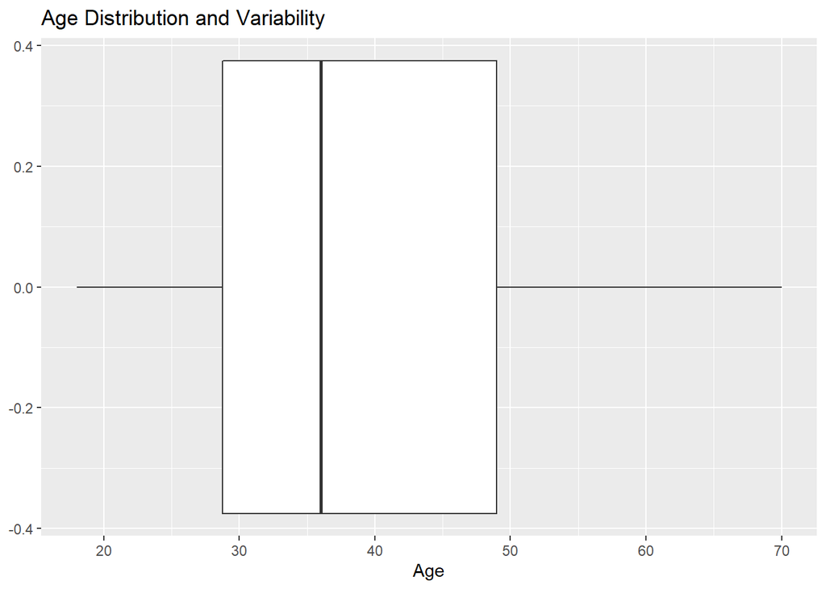

```r
ggplot(data = customer_data, aes(x = Age)) +
  geom_boxplot() +
  ggtitle("Age Distribution and Variability") +
  xlab("Age") +
  theme_get()
```

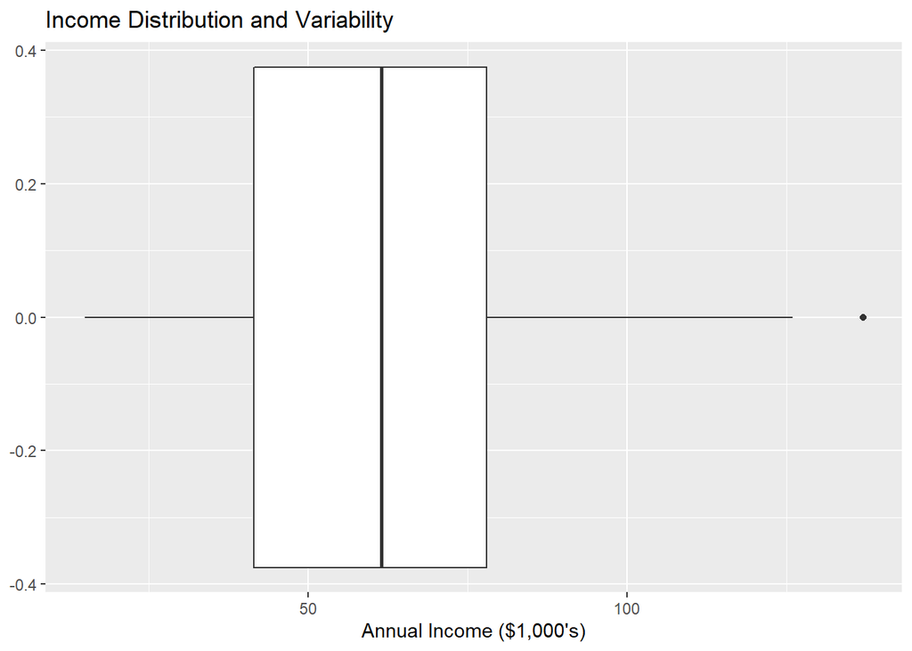

```r
ggplot(data = customer_data, aes(x = Annual.Income..k..)) +
  geom_boxplot() +
  ggtitle("Income Distribution and Variability") +
  xlab("Annual Income ($1,000's)") +
  theme_get()
```

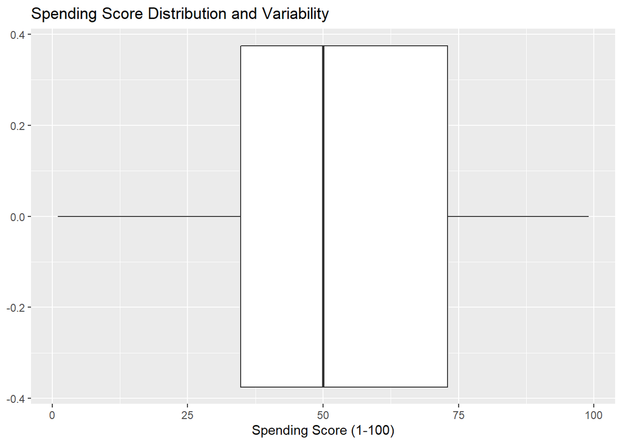

```r
ggplot(data = customer_data, aes(x = Spending.Score..1.100.)) +
  geom_boxplot() +
  ggtitle("Spending Score Distribution and Variability") +
  xlab("Spending Score (1-100)") +
  theme_get()
```

### Histograms (By Gender)

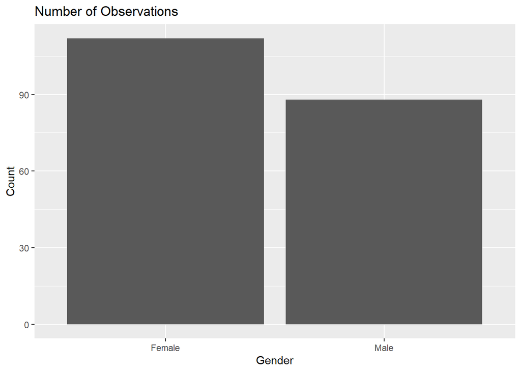

```r
ggplot(data = customer_data, mapping = aes(x=Gender)) +
  geom_bar() +
  ggtitle ("Number of Observations") +
  xlab("Gender") +
  ylab("Count") +
  theme_get()
```

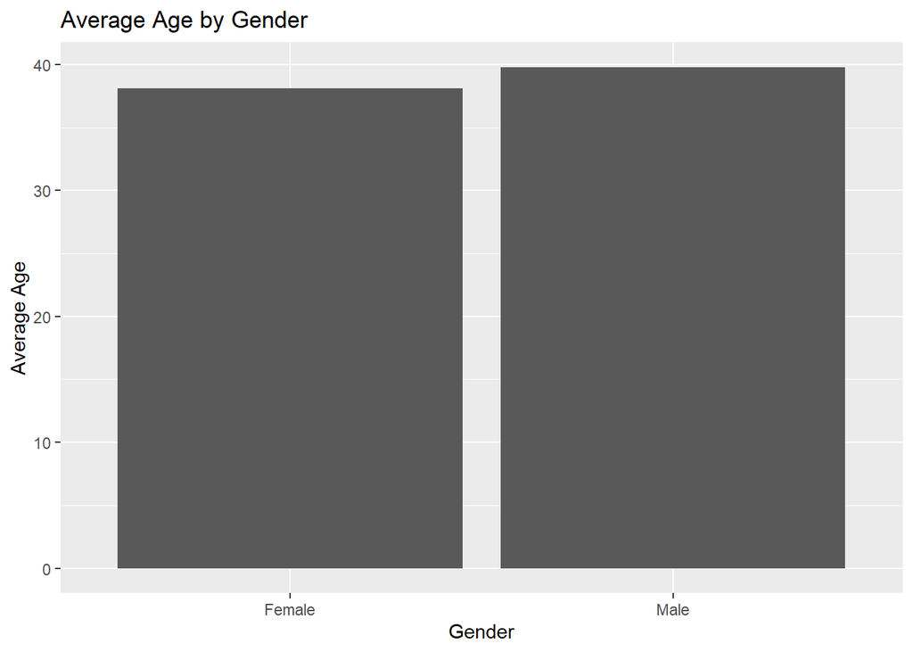

```r
ggplot(data = summarized_avgs_by_gender, mapping = aes(x=Gender, y=Average_Age)) +
  geom_histogram(stat="identity") +
  ggtitle ("Average Age by Gender") +
  xlab("Gender") +
  ylab("Average Age") +
  theme_get()
```

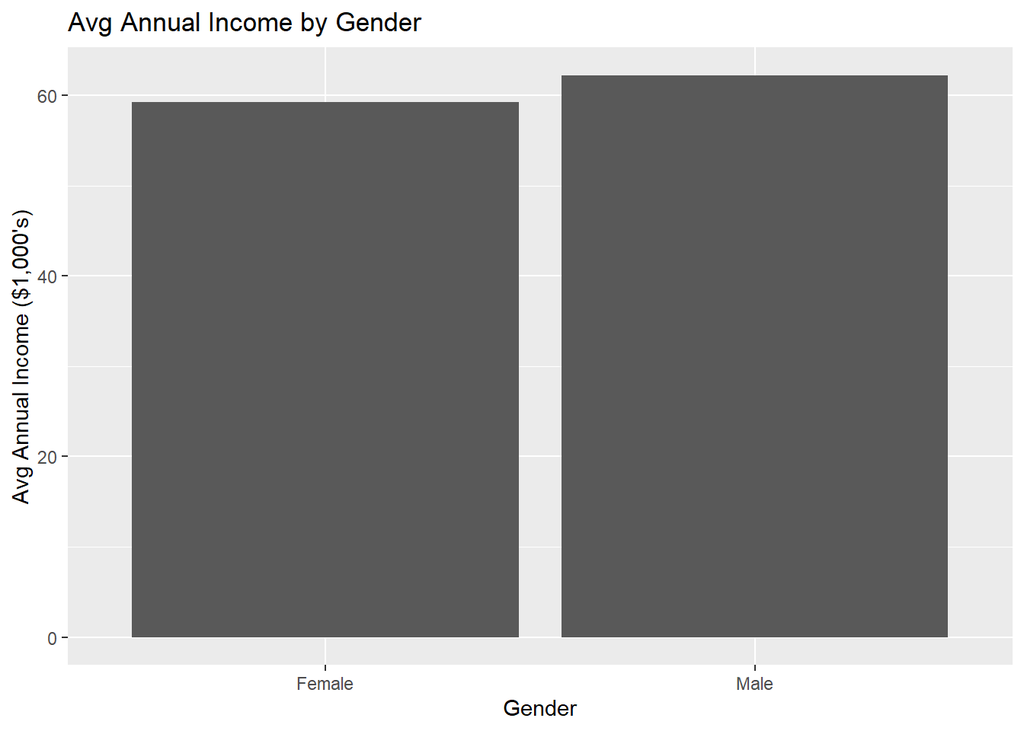

```r
ggplot(data = summarized_avgs_by_gender, mapping = aes(x=Gender, y=Average_Annual_Income)) +
  geom_histogram(stat="identity") +
  ggtitle ("Avg Annual Income by Gender") +
  xlab("Gender") +
  ylab("Avg Annual Income ($1,000's)") +
  theme_get()
```

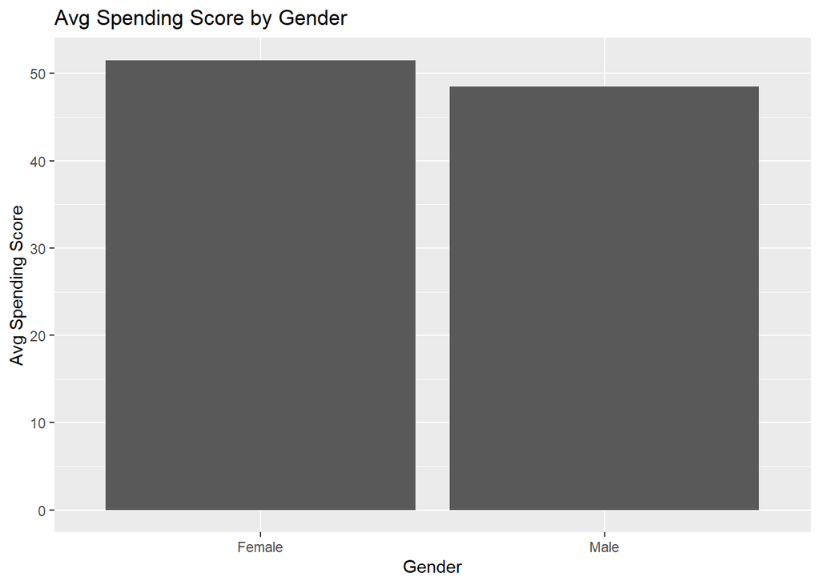

```r
ggplot(data = summarized_avgs_by_gender, mapping = aes(x=Gender, y=Avergae_Spending)) +
  geom_histogram(stat="identity") +
  ggtitle ("Avg Spending Score by Gender") +
  xlab("Gender") +
  ylab("Avg Spending Score") +
  theme_get()
```

### Histograms (By Age Group)

```r
#         ADDING AN AGE GROUP COLUMN TO THE CUSTOMER DATA DF
age_cut <- cut(customer_data$Age, breaks = c(18, 30, 40, 50, 60, 70, 80), right = FALSE)
customer_data_2 <- data.frame(customer_data, Age_Group = age_cut)
head(customer_data_2)
```

```
##   CustomerID Gender Age Annual.Income..k.. Spending.Score..1.100. Age_Group
## 1          1   Male  19                 15                     39   [18,30)
## 2          2   Male  21                 15                     81   [18,30)
## 3          3 Female  20                 16                      6   [18,30)
## 4          4 Female  23                 16                     77   [18,30)
## 5          5 Female  31                 17                     40   [30,40)
## 6          6 Female  22                 17                     76   [18,30)
```

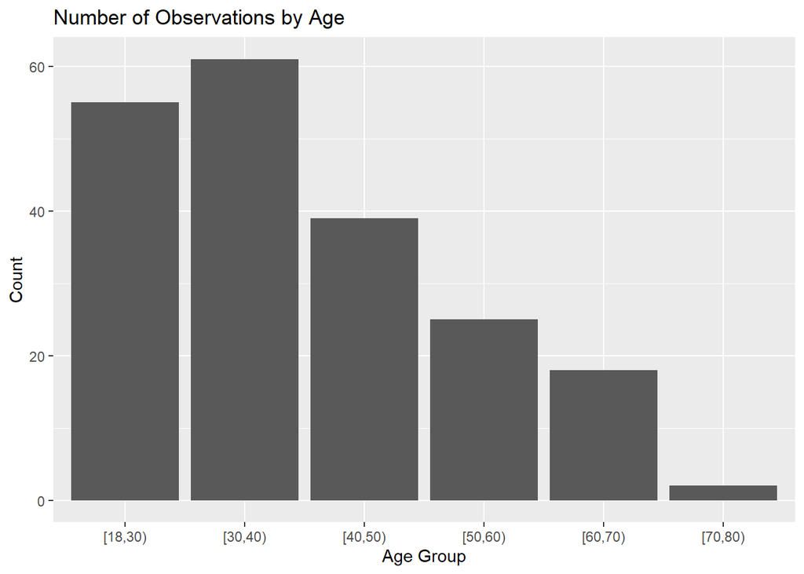

```r
ggplot(customer_data_2, aes(x = Age_Group)) +
  geom_bar() +
  ggtitle ("Number of Observations by Age") +
  xlab("Age Group") +
  ylab("Count") +
  theme_get()
```

```r
income_by_age_group <- aggregate(
  x = customer_data_2$Annual.Income..k..,
  by = list(customer_data_2$Age_Group),
  FUN = mean
)
income_by_age_group
```

```
##   Group.1        x
## 1 [18,30) 52.54545
## 2 [30,40) 70.18033
## 3 [40,50) 63.94872
## 4 [50,60) 58.68000
## 5 [60,70) 49.16667
## 6 [70,80) 47.50000
```

```r
spending_by_age_group <- aggregate(
  x = customer_data_2$Spending.Score..1.100.,
  by = list(customer_data_2$Age_Group),
  FUN = mean
)
spending_by_age_group
```

```
##   Group.1        x
## 1 [18,30) 58.58182
## 2 [30,40) 61.09836
## 3 [40,50) 34.94872
## 4 [50,60) 34.72000
## 5 [60,70) 41.61111
## 6 [70,80) 55.50000
```

```r
summarized_avgs_by_age_group <- data.frame(
  Age_Group = income_by_age_group$Group.1,
  Avg_Income = income_by_age_group$x,
  Avg_Spending = spending_by_age_group$x
)
summarized_avgs_by_age_group
```

```
##   Age_Group Avg_Income Avg_Spending
## 1   [18,30)   52.54545     58.58182
## 2   [30,40)   70.18033     61.09836
## 3   [40,50)   63.94872     34.94872
## 4   [50,60)   58.68000     34.72000
## 5   [60,70)   49.16667     41.61111
## 6   [70,80)   47.50000     55.50000
```

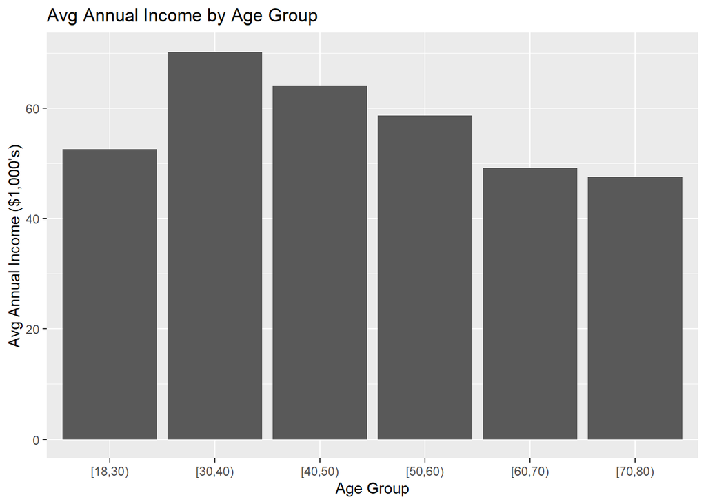

```r
ggplot(data = summarized_avgs_by_age_group, mapping = aes(x=Age_Group, y=Avg_Income)) +
  geom_histogram(stat="identity") +
  ggtitle ("Avg Annual Income by Age Group") +
  xlab("Age Group") +
  ylab("Avg Annual Income ($1,000's)") +
  theme_get()
```

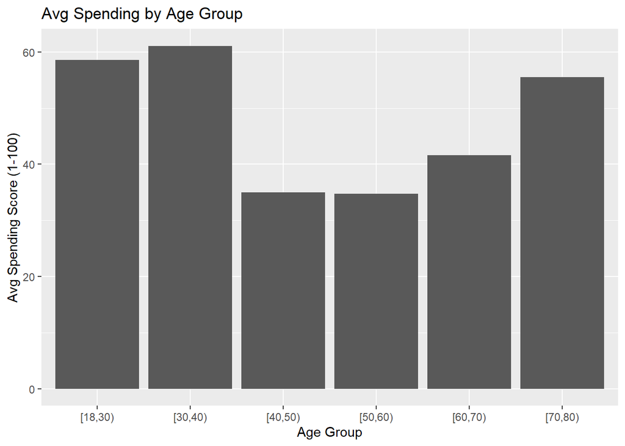

```r
ggplot(data = summarized_avgs_by_age_group, mapping = aes(x=Age_Group, y=Avg_Spending)) +
  geom_histogram(stat="identity") +
  ggtitle ("Avg Spending by Age Group") +
  xlab("Age Group") +
  ylab("Avg Spending Score (1-100)") +
  theme_get()
```

### Scatterplot

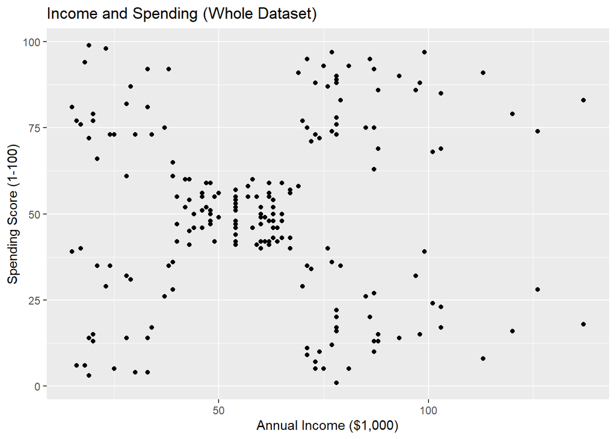

```r
ggplot(data = customer_data, mapping = aes(x=Annual.Income..k.., y=Spending.Score..1.100.)) +
  geom_point() +
  ggtitle("Income and Spending (Whole Dataset)") +
  xlab("Annual Income ($1,000)") +
  ylab("Spending Score (1-100)") +
  theme_get()
```

```r
male_df <- customer_data_2[customer_data_2$Gender == "Male", ]
head(male_df)
```

```
##    CustomerID Gender Age Annual.Income..k.. Spending.Score..1.100. Age_Group
## 1           1   Male  19                 15                     39   [18,30)
## 2           2   Male  21                 15                     81   [18,30)
## 9           9   Male  64                 19                      3   [60,70)
## 11         11   Male  67                 19                     14   [60,70)
## 15         15   Male  37                 20                     13   [30,40)
## 16         16   Male  22                 20                     79   [18,30)
```

```r
female_df <- customer_data_2[customer_data_2$Gender == "Female", ]
head(female_df)
```

```
##   CustomerID Gender Age Annual.Income..k.. Spending.Score..1.100. Age_Group
## 3          3 Female  20                 16                      6   [18,30)
## 4          4 Female  23                 16                     77   [18,30)
## 5          5 Female  31                 17                     40   [30,40)
## 6          6 Female  22                 17                     76   [18,30)
## 7          7 Female  35                 18                      6   [30,40)
## 8          8 Female  23                 18                     94   [18,30)
```

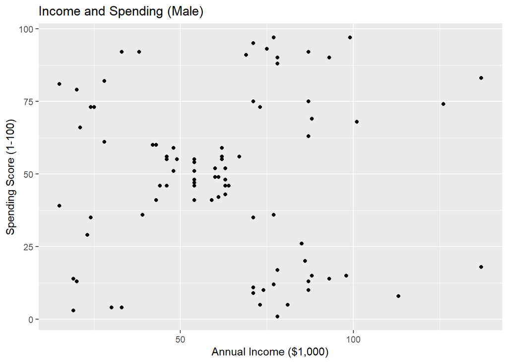

```r
ggplot(data = male_df, mapping = aes(x=Annual.Income..k.., y=Spending.Score..1.100.)) +
  geom_point() +
  ggtitle("Income and Spending (Male)") +
  xlab("Annual Income ($1,000)") +
  ylab("Spending Score (1-100)") +
  theme_get()
```

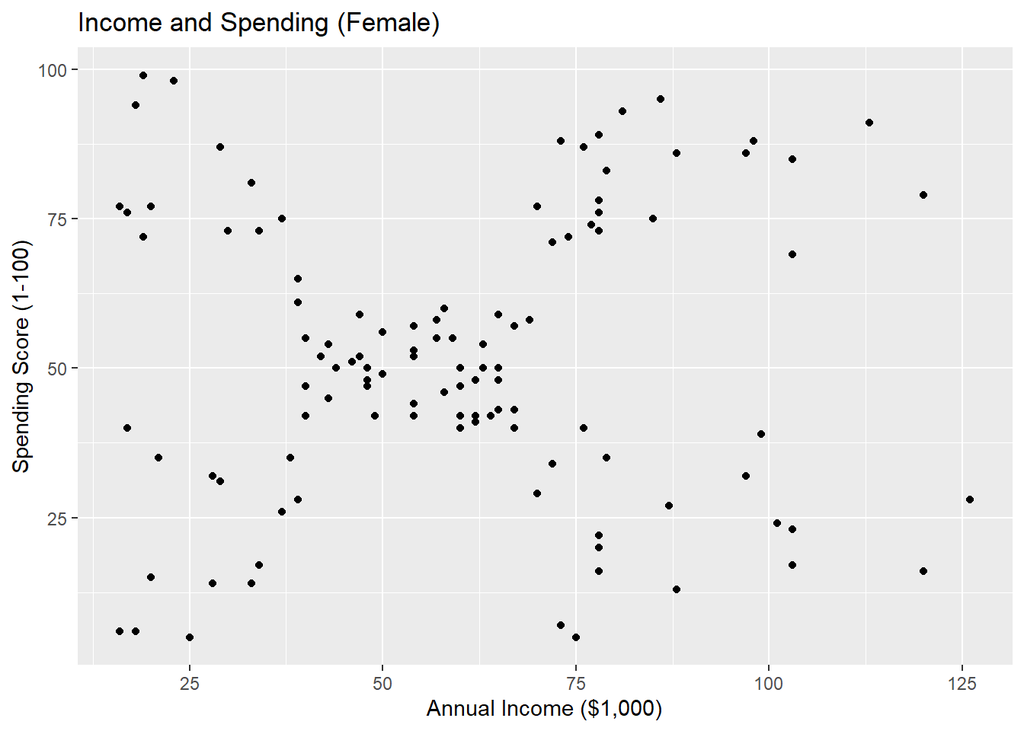

```r
ggplot(data = female_df, mapping = aes(x=Annual.Income..k.., y=Spending.Score..1.100.)) +
  geom_point() +
  ggtitle("Income and Spending (Female)") +
  xlab("Annual Income ($1,000)") +
  ylab("Spending Score (1-100)") +
  theme_get()
```

# Probability and Statistical Analysis

### Distribution

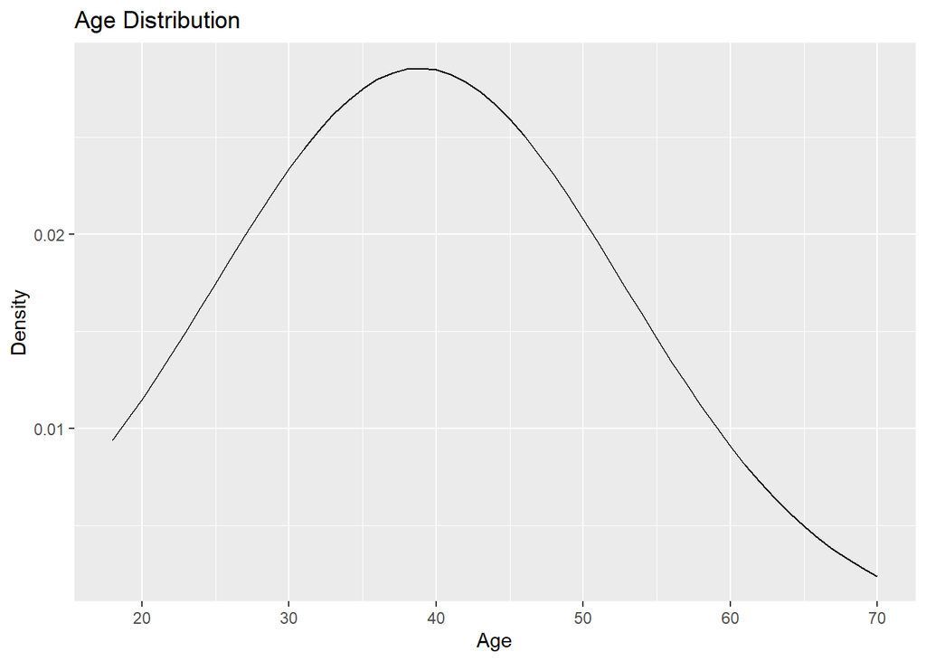

```r
age.range <- min(customer_data$Age):max(customer_data$Age)
age.mean <- mean(customer_data$Age)
age.sd <- sd(customer_data$Age)
age.dist <- dnorm(age.range, mean = age.mean, sd = age.sd)
age.df <- data.frame(Age = age.range, Density = age.dist)

ggplot(age.df, aes(x = Age, y = Density)) +
  geom_line() +
  ggtitle("Age Distribution")
```

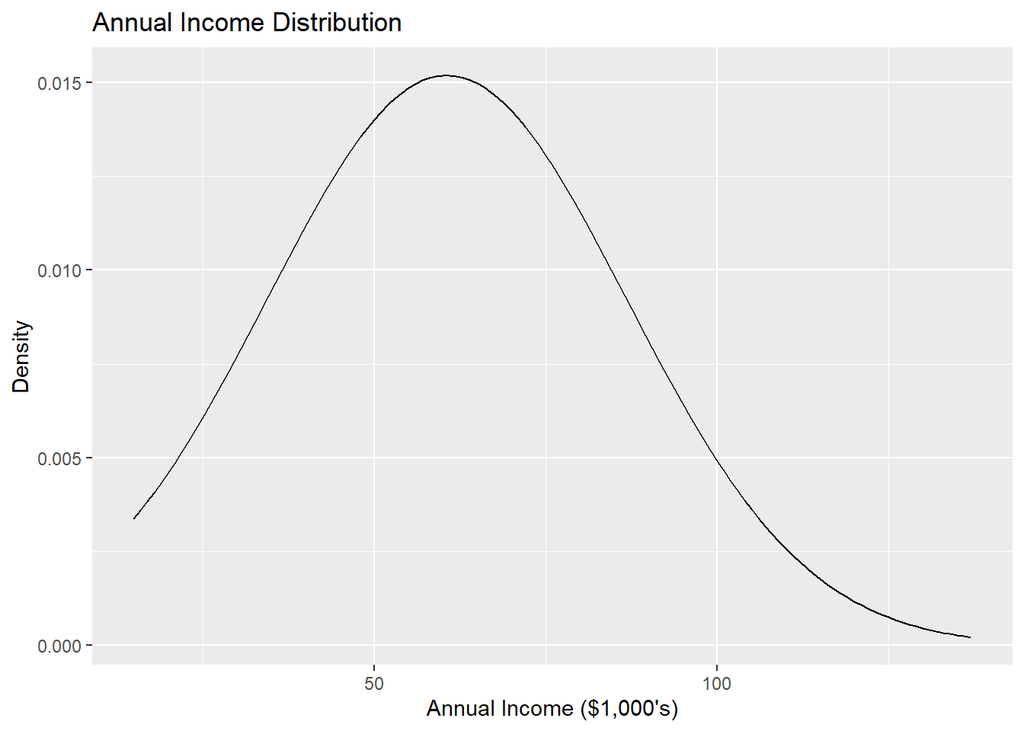

```r
income.range <- min(customer_data$Annual.Income..k..):max(customer_data$Annual.Income..k..)
income.mean <- mean(customer_data$Annual.Income..k..)
income.sd <- sd(customer_data$Annual.Income..k..)
income.dist <- dnorm(income.range, mean = income.mean, sd = income.sd)
income.df <- data.frame(Income = income.range, Density = income.dist)

ggplot(income.df, aes(x = Income, y = Density)) +
  geom_line() +
  ggtitle("Annual Income Distribution") +
  xlab("Annual Income ($1,000's)")
```

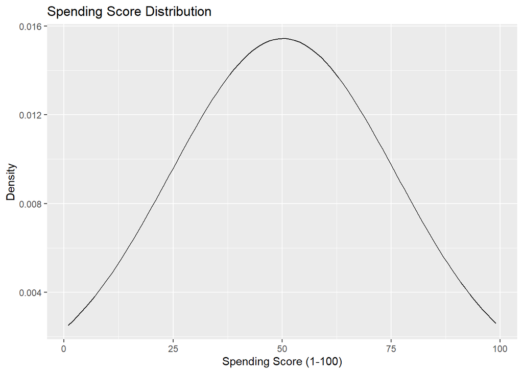

```r
spending.range <- min(customer_data$Spending.Score..1.100.):max(customer_data$Spending.Score..1.100.)
spending.mean <- mean(customer_data$Spending.Score..1.100.)
spending.sd <- sd(customer_data$Spending.Score..1.100.)
spending.dist <- dnorm(spending.range, mean = spending.mean, sd = spending.sd)
spending.df <- data.frame(Spending = spending.range, Density = spending.dist)

ggplot(spending.df, aes(x = Spending, y = Density)) +
  geom_line() +
  ggtitle("Spending Score Distribution") +
  xlab("Spending Score (1-100)")
```